# Pelagie, Eden, Sepages data join

M. Rolland

2020-06-16

To do:

- List variables of interest (finalise DAG)
- Alcohol?
- Define
  - gestation duration / pregnancy start date
  - delivery categorical var
  - tobacco var
- Clarify eden pelagie vars:
  - health issues
  - work (when?)
- Get exposure + geolocation datasets for Eden, Pelagie, Sepages
- harmonise sepages varnames and coding
- Create Sepages health pb var
- Discuss preterm history
- Discuss EDI var

# 1 Datasets

## 1.1 go_eden_pelagie_2013_07_01.dta

Merge of Eden and Pelagie datasets realised by Otana for her project in **when?**. This dataset will probably be lacking some variables as is was not produced for this study and there have been some modifications since this merge concerning PELAGIE:

> “Depuis 2013, la base Pélagie a été corrigée pour la variable du sexe de l’enfant. Sur votre base, les changements concernent 24 enfants. Ces corrections impactent la génération de la variable SGA” Emie 22/05/2020

Contains outcome and most covariates. Not the exposures.

## 1.2 bdd_grossesse_v4.dta

Latest version of the sepages pregnancy dataset. should contain all sepages outcomes and covariates. Not exposures.

# 2 DAG

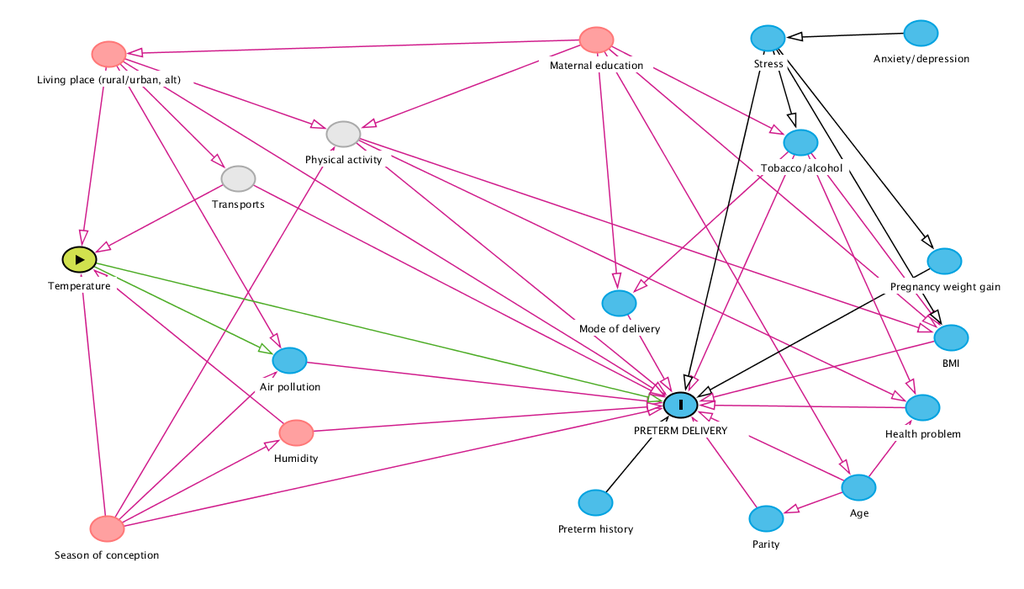

# 3 Available variables

## 3.1 Identifier

- identifier
  - Sepages = `ident`
  - Eden - Pelagie = `go_n_ident`

## 3.2 Pregnancy length

- date of birth
  - Sepages = `po_datedel`
  - Eden - Pelagie = `go_dateacc`

All available variables in Sepages:

- `po_gd` [numeric] Gestational duration, completed weeks
- `po_gd_sq` [numeric] Gestational duration, completed weeks (squared)
- `po_gd_lmp` [numeric] Gestational duration, LMP-based, weeks Mean (sd)
- `po_preterm` [numeric] Preterm delivery (N/Y)
- `po_datec` [Date] Fertilization date
- `po_month_conception` [numeric] Month of conception Mean (sd)
- `po_seasonc` [numeric] Season of conception

## 3.3 Delivery

Sepages:

- `po_delmod` [numeric] Delivery mode (2 categories 1: vaginal/2: c-section)
- `cy1hao1_q07` Début travail (spontané/déclenché/césarienne avt travail)
- `cy1hao1_q10` Naissance par (voie basse non instrumentale/extraction voie basse instrumentale/césarienne programmée/césarienne en urgence)

Eden pelagie:

- `go_modetra` [haven_labelled] mode debut travail (spontane/declenche ou césarienne avt travail)
- `go_modeacc` [haven_labelled] mode accouchement (voie basse/césarienne avt travail/césarienne pdt travail)

## 3.4 Personnal characteristics

- Maternal age at conception
  - Sepages = `mo_age`
  - Eden - Pelagie = `go_agef`
- Maternal heightf
  - Sepages = `mo_he`
  - Eden - Pelagie = `go_taillef`
- Maternal weight
  - Sepages = `mo_we_bepr` (before pregnancy)
  - Eden - Pelagie = `go_poifag`
- Pre pregnancy BMI
  - Sepages = `mo_bmi_bepr`
  - Eden - Pelagie = `go_bmifag`

## 3.5 Tobacco

Sepages tobacco vars:

- `mo_tob_avgr` [numeric] Maternal smoking before pregnancy, cig./day
- `mo_tob_grstt1` [numeric] Maternal smoking between preg. conception and detection, cig./day
- `mo_tob_grstt1_yn` [numeric] Maternal smoking between preg. conception and detection, N/Y
- `mo_tob_grstt1_yn1` [numeric] Maternal smoking between preg. conception and detection above 1 cig./day, N/Y
- `mo_tob_grt1` [numeric] Maternal smoking during 1st trim of pregnancy, after diagnosis, cig./day
- `mo_tob_grt1_yn` [numeric] Maternal smoking during 1st trim of pregnancy, after diagnosis, N/Y
- `mo_tob_grt1_yn1` [numeric] Maternal smoking during 1st trim of pregnancy, after diagnosis, above 1 cig./day
- `mo_tob_grt2` [numeric] Maternal smoking during 2nd trim of pregnancy, cig./day Mean (sd)
- `mo_tob_grt2_yn` [numeric] Maternal smoking during 2nd trim of pregnancy, N/Y
- `mo_tob_grt2_yn1` [numeric] Maternal smoking during 2nd trim of pregnancy above 1 cig./day, N/Y
- `mo_tob_grt3` [numeric] Maternal smoking during 3rd trim of pregnancy, cig./day
- `mo_tob_grt3_yn` [numeric] Maternal smoking during 3rd trim of pregnancy, N/Y
- `mo_tob_grt3_yn1` [numeric] Maternal smoking during 3rd trim of pregnancy above 1 cig./day, N/Y
- `mo_tob_gr_anyt_yn` [numeric] Maternal smoking during any trim of diagnosed pregnancy, N/Y
- `mo_tob_gr_anyt_yn1` [numeric] Maternal smoking during any trim of diagnosed pregnancy above 1 cig./day, N/Y

All Eden - Pelagie tobacco vars:

- `go_tabac` [numeric] nb cig/jr trim1 pour EDEN, inclusion pour PELAGIE
- `go_tabaccl` [haven_labelled] nb cig/jr en classes trim1 pour EDEN, inclusion pour PELAGIE
- `go_tabapass` [haven_labelled] tabagisme passif de la mère

## 3.6 Parity

- Sepages = `mo_par`
- Eden - Pelagie = `go_parite`

## 3.7 Health issues

- Sepages first general question:
  - `mt1haa1_q40` = AT T1: “depuis le début de votre grossesse, est-ce qu’un médecin ou une sage-femme vous a diagnostiqué des complications liées à votre grossesse ?”
- Hypertension gravidique
  - Sepages =
    - `mt1haa1_q40p1` = Hypertension à T1 (see `mt1haa1_q40` first)
    - `mt1haa1_q40p2` = Nombre de SA Hypertension à T1 (see `mt1haa1_q40` first)
    - `mt3haf1_q01` = At T3: “Depuis le début de votre grossesse, vous a-t-on diagnostiqué de l’hypertension?”
    - `mt3haf1_q01p1` = Nombre SA Hypertension (see `mt3haf1_q01` first)
  - Eden - Pelagie = `go_htg`
- Gestational diabetes
  - Sepages =
    - `mt1haa1_q40p7` = diabète gestationnel T1 (see `mt1haa1_q40` first)
    - `mt1haa1_q40p8` = nombre SA diabète gestationnel T1 (see `mt1haa1_q40` first)
    - `mt3haf1_q04` = At T3: “Depuis le début de votre grossesse, vous a-t-on diagnostiqué du diabète gestationnel?”
    - `mt3haf1_q04p1` = Nombre SA diabète gestationnel (see `mt3haf1_q04` first)
  - Eden - Pelagie = `go_diabges`

## 3.8 Habitation

Waiting for exposure dataset which includes geolocation.

- rural/urban
- altitude
- house/flat
- use of stairs (first floor or more? elevator?)

## 3.9 SES

- Education level
  - Sepages = `mo_dipl`
    - 1 primaire collège
    - 2 BEP CAP Lycée
    - 3 1-2 années après bac
    - 4 3-4 années après bac
    - 5 5+ années après bac
  - Eden - Pelagie = `go_nivetude`
    - 1 études primaires
    - 2 CAP BEP ou apprentissage
    - 3 niveau bac
    - 4 bac +2
    - 5 >=bac+3
- Mother employed yes/no
  - Sepages:
    - `mt3sad1_q02` at T3: “Est-ce que vous avez travaillé pendant votre grossesse ?”
    - `mt3sad1_q02p1` “Quelle est la date officielle du début de votre congé maternité ?”
  - Eden - Pelagie: `go_travm` [haven_labelled] occupation d’un emploi par la mère
- Father employed yes/no
  - Sepages
  - Eden - Pelagie `go_travp` [haven_labelled] occupation d’un emploi par le père

Et celles-ci?

`bhz_8km_cote` [numeric] Bhz_8km_cote `distancem` [numeric] DistanceM

# 4 Final data set creation

Performed in `R/data_preparation.R`.